# Wage other Predictors Problem

This is Problem 7 For ISLR’s Chapter 7 Applied Section “The Wage data set contains a number of other features not explored in this chapter, such as marital status (maritl), job class (jobclass), and others. Explore the relationships between some of these other predictors and wage, and use non-linear fitting techniques in order to fit flexible models to the data. Create plots of the results obtained, and write a summary of your findings.”

```r
library(ISLR)
library(tidyverse)
library(boot)
set.seed(1)
names(Wage)

ggplot(data = Wage) +
  geom_point(mapping = aes(x=age,y=wage, col = maritl))
ggplot(data = Wage) +
  geom_point(mapping = aes(x=age,y=wage, col = jobclass))
summary(Wage$maritl)
summary(Wage$jobclass)
```

[output not shown]

We’ll be using analysis of variance to see which features to add and which not to add By analyzing the p-values, combined with the analysis of variance for the fourth predictors, we see that including the marital status and the and jobclass are good predictors for the wage of a given individual, and through our analysis of variance, we see the fourth model, the model with both of those predictors included, did better than the original model without the predictors.

```r
library(gam)
library(splines)
library(car)
gam.m1 = gam(wage ~ lo(year, span = .7) + s(age, df = 5) + education, data = Wage)
```

```
non-list contrasts argument ignored
```

```r
gam.m2 = gam(wage ~ lo(year, span = .7) + s(age,df=5) + education +jobclass, data = Wage)
```

```
non-list contrasts argument ignored
```

```r
gam.m3 = gam(wage ~ lo(year, span = .7) + s(age,df=5) + education +maritl, data = Wage)
```

```
non-list contrasts argument ignored
```

```r
gam.m4 = gam(wage ~ lo(year, span = .7) + s(age,df=5) + education +maritl + jobclass, data = Wage)
```

```
non-list contrasts argument ignored
```

```r
anova(gam.m1,gam.m2,gam.m3,gam.m4)
```

```
Analysis of Deviance Table

Model 1: wage ~ lo(year, span = 0.7) + s(age, df = 5) + education
Model 2: wage ~ lo(year, span = 0.7) + s(age, df = 5) + education + jobclass
Model 3: wage ~ lo(year, span = 0.7) + s(age, df = 5) + education + maritl
Model 4: wage ~ lo(year, span = 0.7) + s(age, df = 5) + education + maritl +
    jobclass
  Resid. Df Resid. Dev Df Deviance  Pr(>Chi)
1    2987.1    3691855
2    2986.1    3679689  1    12166 0.0014637 **
3    2983.1    3597526  3    82163  9.53e-15 ***
4    2982.1    3583675  1    13852 0.0006862 ***
---
Signif. codes:  0 ‘***’ 0.001 ‘**’ 0.01 ‘*’ 0.05 ‘.’ 0.1 ‘ ’ 1
```

```r
summary(gam.m4)
```

```
Call: gam(formula = wage ~ lo(year, span = 0.7) + s(age, df = 5) +
    education + maritl + jobclass, data = Wage)
Deviance Residuals:
     Min       1Q   Median       3Q      Max
-108.684  -19.523   -2.588   13.788  213.278

(Dispersion Parameter for gaussian family taken to be 1201.729)

    Null Deviance: 5222086 on 2999 degrees of freedom
Residual Deviance: 3583675 on 2982.099 degrees of freedom
AIC: 29808.03

Number of Local Scoring Iterations: 2

Anova for Parametric Effects
                         Df  Sum Sq Mean Sq F value    Pr(>F)
lo(year, span = 0.7)    1.0   26181   26181  21.786 3.182e-06 ***
s(age, df = 5)          1.0  195235  195235 162.462 < 2.2e-16 ***
education               4.0 1090931  272733 226.950 < 2.2e-16 ***
maritl                  4.0  104905   26226  21.824 < 2.2e-16 ***
jobclass                1.0   14059   14059  11.699 0.0006338 ***
Residuals            2982.1 3583675    1202
---
Signif. codes:  0 ‘***’ 0.001 ‘**’ 0.01 ‘*’ 0.05 ‘.’ 0.1 ‘ ’ 1

Anova for Nonparametric Effects
                     Npar Df  Npar F     Pr(F)
(Intercept)
lo(year, span = 0.7)     1.9  0.7287    0.4762
s(age, df = 5)           4.0 18.4105 5.995e-15 ***
education
maritl
jobclass
---
Signif. codes:  0 ‘***’ 0.001 ‘**’ 0.01 ‘*’ 0.05 ‘.’ 0.1 ‘ ’ 1
```

```r
vif(gam.m4)
```

```
                         GVIF Df GVIF^(1/(2*Df))
lo(year, span = 0.7) 1.005083  1        1.002538
s(age, df = 5)       1.276489  1        1.129818
education            1.131984  4        1.015617
maritl               1.282225  4        1.031562
jobclass             1.111909  1        1.054471
```

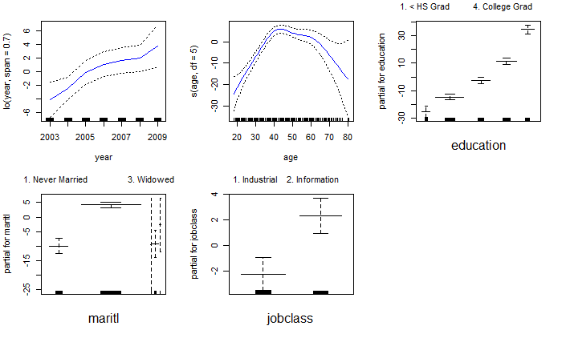

```r
par(mfrow = c(2, 3))
#plot the best fit
plot(gam.m4, se = T, col = "blue")
```